# Esplorazione dataset sul bikesharing a Washington D.C. fra il 2011 e 2012

Gianluca La Malfa

Venezia, Luglio 2022

=========================================

#Introduzione Questo progetto rappresenta l’elaborato finale del corso ‘Dati e Conoscenza’ nell’ambito del Minor in Computer and Data science all’università Ca’Foscari di Venezia. Il dataset utilizzato riguarda una azienda di bike sharing e una agenzia meteo fra il 2011 e il 2012 a Washington D.C. Vi troviamo dati sulla quantità di biciclette date in noleggio e i rispettivi dati sul meteo con una granularità giornaliera.

## Obbiettivi del progetto:

In questo documento si cercherà di analizzare i dati per comprendere al meglio il dataset. Per poi svolgere una analisi di regressione per verificare il grado di correlazione fra la temmmperatura e il numero di biciclette noleggiate dall’azienda di bike sharing.

##Descrizione dataset:

```
- instant: record index
- dteday : date
- season : season (1:springer, 2:summer, 3:fall, 4:winter)
- yr : year (0: 2011, 1:2012)
- mnth : month ( 1 to 12)
- hr : hour (0 to 23)
- holiday : weather day is holiday or not (extracted from http://dchr.dc.gov/page/holiday-schedule)
- weekday : day of the week
- workingday : if day is neither weekend nor holiday is 1, otherwise is 0.
+ weathersit :
    - 1: Clear, Few clouds, Partly cloudy, Partly cloudy
    - 2: Mist + Cloudy, Mist + Broken clouds, Mist + Few clouds, Mist
    - 3: Light Snow, Light Rain + Thunderstorm + Scattered clouds, Light Rain + Scattered clouds
    - 4: Heavy Rain + Ice Pallets + Thunderstorm + Mist, Snow + Fog
- temp : Normalized temperature in Celsius. The values are divided to 41 (max)
- atemp: Normalized feeling temperature in Celsius. The values are divided to 50 (max)
- hum: Normalized humidity. The values are divided to 100 (max)
- windspeed: Normalized wind speed. The values are divided to 67 (max)
- casual: count of casual users
- registered: count of registered users
- cnt: count of total rental bikes including both casual and registered
```

##Fonti:

[1] Fanaee-T, Hadi, and Gama, Joao, “Event labeling combining ensemble detectors and background knowledge”, Progress in Artificial Intelligence (2013): pp. 1-15, Springer Berlin Heidelberg, doi:10.1007/s13748-013-0040-3.

https://data.world/data-society/capital-bikeshare-2011-2012 (day.csv)

=========================================

#Analisi

Importiamo i pacchetti necessari:

```r
library(tidyverse)
```

```r
library(ggplot2)
library(kableExtra)
library(ggridges)
library(broom)
library(ggpubr)
library(dplyr)
library(reshape2)
library(plotly)
library(zoo)
```

Carichiamo il file:

```r
day <- read.csv('C:/Users/user/Documents/RStudio repository/uci-bike-sharing-dataset/day.csv')
```

Formattiamo una tabella per dare un’occhiata alle prime righe del dataset:

```r
head<-day %>%
  head() %>%
  kable(escape = F,
        caption = "<b>Tabella 1.</b> Estratto delle prime sei righe del data frame `day` in formato `tibble`.") %>%
  kable_paper(full_width = F)
head
```

**Tabella 1.** Estratto delle prime sei righe del data frame `day` in formato `tibble`.

| instant | dteday | season | yr | mnth | holiday | weekday | workingday | weathersit | temp | atemp | hum | windspeed | casual | registered | cnt |
| --- | --- | --- | --- | --- | --- | --- | --- | --- | --- | --- | --- | --- | --- | --- | --- |
| 1 | 2011-01-01 | 1 | 0 | 1 | 0 | 6 | 0 | 2 | 0.344167 | 0.363625 | 0.805833 | 0.1604460 | 331 | 654 | 985 |
| 2 | 2011-01-02 | 1 | 0 | 1 | 0 | 0 | 0 | 2 | 0.363478 | 0.353739 | 0.696087 | 0.2485390 | 131 | 670 | 801 |
| 3 | 2011-01-03 | 1 | 0 | 1 | 0 | 1 | 1 | 1 | 0.196364 | 0.189405 | 0.437273 | 0.2483090 | 120 | 1229 | 1349 |
| 4 | 2011-01-04 | 1 | 0 | 1 | 0 | 2 | 1 | 1 | 0.200000 | 0.212122 | 0.590435 | 0.1602960 | 108 | 1454 | 1562 |
| 5 | 2011-01-05 | 1 | 0 | 1 | 0 | 3 | 1 | 1 | 0.226957 | 0.229270 | 0.436957 | 0.1869000 | 82 | 1518 | 1600 |
| 6 | 2011-01-06 | 1 | 0 | 1 | 0 | 4 | 1 | 1 | 0.204348 | 0.233209 | 0.518261 | 0.0895652 | 88 | 1518 | 1606 |

Cambiamo il formato della colonna dteday da stringa a data:

```r
bsh <- day %>%
  mutate(dteday = as.Date(dteday, format="%Y-%m-%d"), temp = temp*41)

#bsh$dteday <- as.Date(bsh$dteday, format="%Y-%m-%d")
```

Cerchiamo di coprendere la distribuzione di aclune variabili:

```r
sommario <- bsh %>%
  select(dteday, holiday, weathersit, temp, atemp, hum,  windspeed, casual, registered, cnt)
summary(sommario)
```

```
##      dteday              holiday          weathersit         temp
##  Min.   :2011-01-01   Min.   :0.00000   Min.   :1.000   Min.   : 2.424
##  1st Qu.:2011-07-02   1st Qu.:0.00000   1st Qu.:1.000   1st Qu.:13.820
##  Median :2012-01-01   Median :0.00000   Median :1.000   Median :20.432
##  Mean   :2012-01-01   Mean   :0.02873   Mean   :1.395   Mean   :20.311
##  3rd Qu.:2012-07-01   3rd Qu.:0.00000   3rd Qu.:2.000   3rd Qu.:26.872
##  Max.   :2012-12-31   Max.   :1.00000   Max.   :3.000   Max.   :35.328
##      atemp              hum           windspeed           casual
##  Min.   :0.07907   Min.   :0.0000   Min.   :0.02239   Min.   :   2.0
##  1st Qu.:0.33784   1st Qu.:0.5200   1st Qu.:0.13495   1st Qu.: 315.5
##  Median :0.48673   Median :0.6267   Median :0.18097   Median : 713.0
##  Mean   :0.47435   Mean   :0.6279   Mean   :0.19049   Mean   : 848.2
##  3rd Qu.:0.60860   3rd Qu.:0.7302   3rd Qu.:0.23321   3rd Qu.:1096.0
##  Max.   :0.84090   Max.   :0.9725   Max.   :0.50746   Max.   :3410.0
##    registered        cnt
##  Min.   :  20   Min.   :  22
##  1st Qu.:2497   1st Qu.:3152
##  Median :3662   Median :4548
##  Mean   :3656   Mean   :4504
##  3rd Qu.:4776   3rd Qu.:5956
##  Max.   :6946   Max.   :8714
```

Controlliamo che cnt sia la somma di casual e registered:

```r
all(bsh$casual + bsh$registered == bsh$cnt)
```

```
## [1] TRUE
```

Estraiamo qualche informazione in più su alcune variabili di interesse:

```r
variabilita_conto <- bsh %>%
  summarise(
    media_tot = mean(cnt, na.rm=T),
    varianza_tot = var(cnt, na.rm = T),
    dev_std_tot = sd(cnt, na.rm = T),
    cv_tot = (dev_std_tot/media_tot),
    IQR_tot = IQR(cnt, na.rm = T),
    media_reg = mean(registered, na.rm=T),
    varianza_reg = var(registered, na.rm = T),
    dev_std_reg = sd(registered, na.rm = T),
    cv_reg = (dev_std_reg/media_reg),
    IQR_reg = IQR(registered, na.rm = T),
    media_nreg = mean(casual, na.rm=T),
    varianza_nreg = var(casual, na.rm = T),
    dev_std_nreg = sd(casual, na.rm = T),
    cv_nreg = (dev_std_nreg/media_nreg),
    IQR_nreg = IQR(casual, na.rm = T),
    media_temp = mean(temp, na.rm=T),
    varianza_temp = var(temp, na.rm = T),
    dev_std_temp = sd(temp, na.rm = T),
    cv_temp = (dev_std_temp/media_temp),
    IQR_temp = IQR(temp, na.rm = T),
  )%>%
    kable(escape = F,
          caption = "<b>Tabella 2.</b> Distribuzione e variabilità`.") %>%
    kable_styling(bootstrap_options = "hover", full_width = F) %>%
    add_header_above(header = c("Misure statistiche totale noleggi" = 5, "Misure statistiche noleggi utenti registrati" = 5, "Misure statistiche noleggi utenti non registrati" = 5, "Misure statistiche temperature" = 5), italic = T)

variabilita_conto
```

**Tabella 2.** Distribuzione e variabilità`.

| Misure statistiche totale noleggi media_tot | Misure statistiche totale noleggi varianza_tot | Misure statistiche totale noleggi dev_std_tot | Misure statistiche totale noleggi cv_tot | Misure statistiche totale noleggi IQR_tot | Misure statistiche noleggi utenti registrati media_reg | Misure statistiche noleggi utenti registrati varianza_reg | Misure statistiche noleggi utenti registrati dev_std_reg | Misure statistiche noleggi utenti registrati cv_reg | Misure statistiche noleggi utenti registrati IQR_reg | Misure statistiche noleggi utenti non registrati media_nreg | Misure statistiche noleggi utenti non registrati varianza_nreg | Misure statistiche noleggi utenti non registrati dev_std_nreg | Misure statistiche noleggi utenti non registrati cv_nreg | Misure statistiche noleggi utenti non registrati IQR_nreg | Misure statistiche temperature media_temp | Misure statistiche temperature varianza_temp | Misure statistiche temperature dev_std_temp | Misure statistiche temperature cv_temp | Misure statistiche temperature IQR_temp |
| --- | --- | --- | --- | --- | --- | --- | --- | --- | --- | --- | --- | --- | --- | --- | --- | --- | --- | --- | --- |
| 4504.349 | 3752788 | 1937.211 | 0.4300758 | 2804 | 3656.172 | 2434400 | 1560.256 | 0.4267458 | 2279.5 | 848.1765 | 471450.4 | 686.6225 | 0.8095279 | 780.5 | 20.31078 | 56.32639 | 7.505091 | 0.3695128 | 13.05165 |

Il coefficiente di variazione è meggiore per i noleggi di utenti non registrati, probabilmente in quanto meno spinti a noleggiare regolarmente.

Visualizziamo la distribuzione della temperatura per mese:

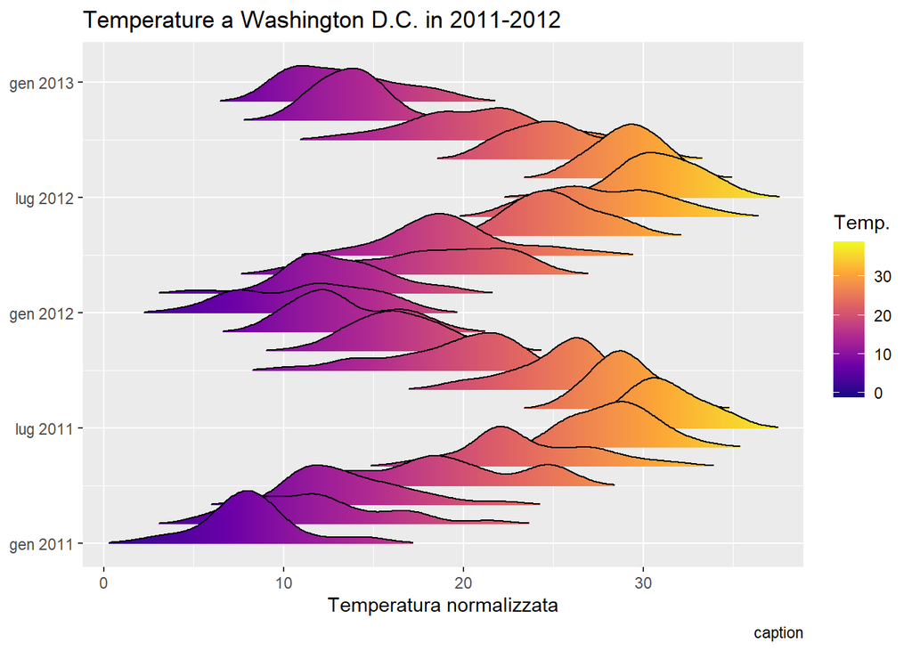

```r
bsh$monthyear <- as.yearmon(bsh$dteday, "%b %Y")

ggplot(bsh, aes(x = temp, y=monthyear, group=monthyear, fill = stat(x), caption ="Fig. 1")) +
  geom_density_ridges_gradient(scale = 3, rel_min_height = 0.01) +
  scale_x_continuous(expand = c(0, 0)) +
  scale_fill_viridis_c(name = "Temp.", option = "C") +
  coord_cartesian(clip = "off") +
  labs(x="Temperatura normalizzata", title = 'Temperature a Washington D.C. in 2011-2012') +
  theme(axis.title.y = element_blank())
```

Visualizziamo la distribuzione del totale di biciclette noleggiate per anno (0=2011, 1=2012):

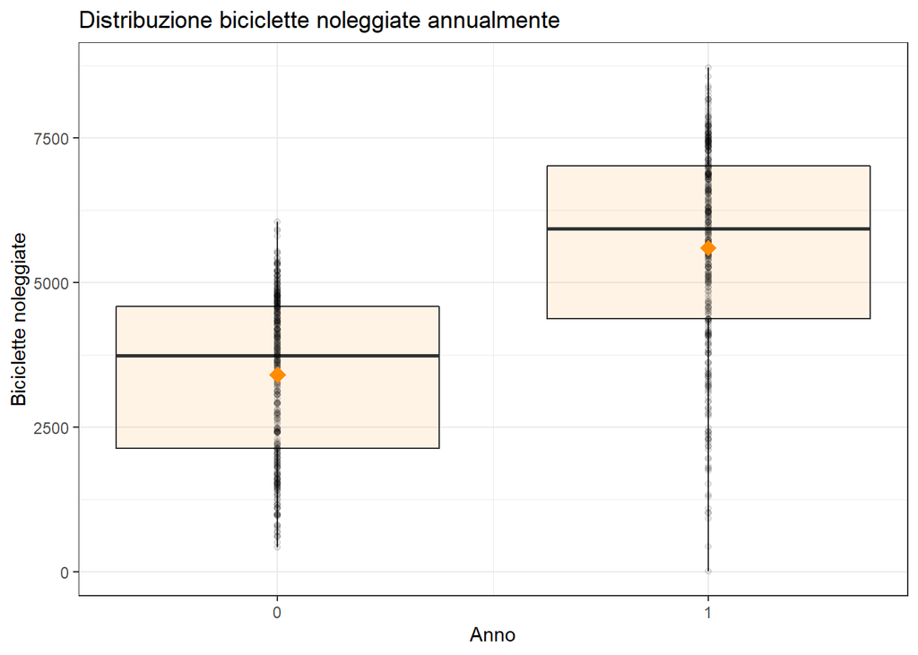

```r
ggplot(data = bsh, aes(x = yr, y = cnt, group = yr)) +
  geom_boxplot(fill = "darkorange", alpha=0.1, coef = 10) +
  geom_jitter(width = 0, height = 0, alpha = 0.1, col = "black") +
  stat_summary(fun = "mean", geom = "point", col = "darkorange", pch = 18, size = 4) +
  labs(x="Anno", y = "Biciclette noleggiate", title = "Distribuzione biciclette noleggiate annualmente")+
  scale_x_continuous(breaks = 0:2)+
  theme_bw()
```

Visualizziamo la distribuzione del totale di biciclette noleggiate mensilmente:

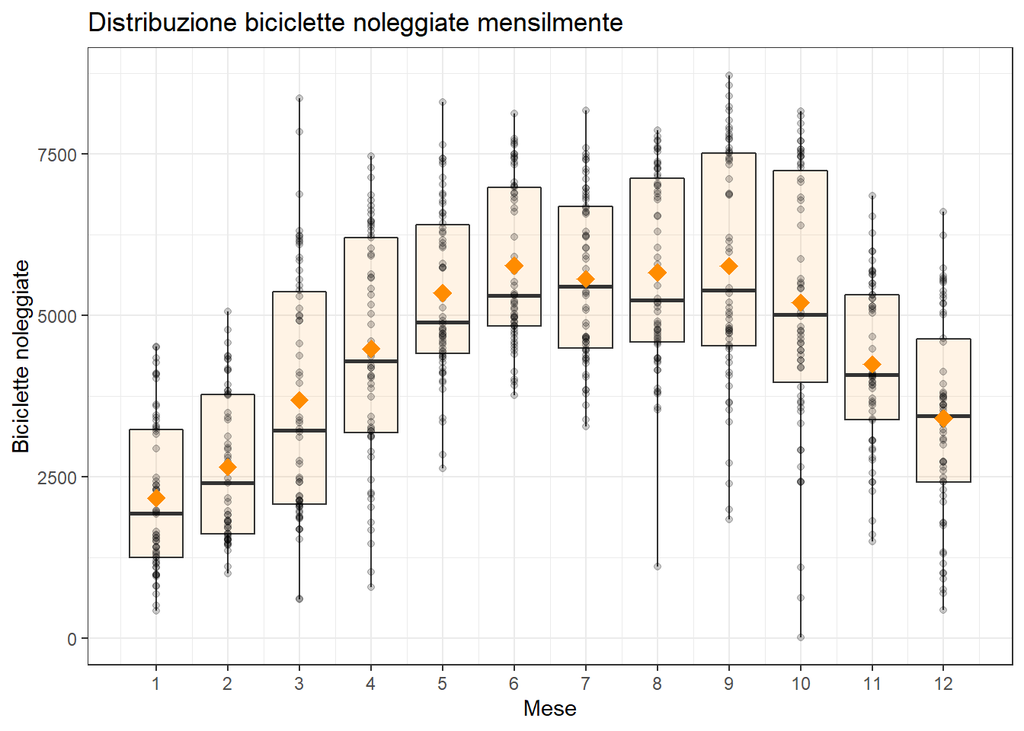

```r
ggplot(data = bsh, aes(x = mnth, y = cnt, group = mnth)) +
  geom_boxplot(fill = "darkorange", alpha=0.1, coef = 10) +
  geom_jitter(width = 0, height = 0, alpha = 0.2, col = "black") +
  stat_summary(fun = "mean", geom = "point", col = "darkorange", pch = 18, size = 4) +
  labs(x="Mese", y = "Biciclette noleggiate", title = "Distribuzione biciclette noleggiate mensilmente")+
  scale_x_continuous(breaks = 1:12)+
  theme_bw()
```

Visualizziamo la distribuzione del totale di biciclette noleggiate per giorno della settimana, 0=Domenica, 1=Lunedì:

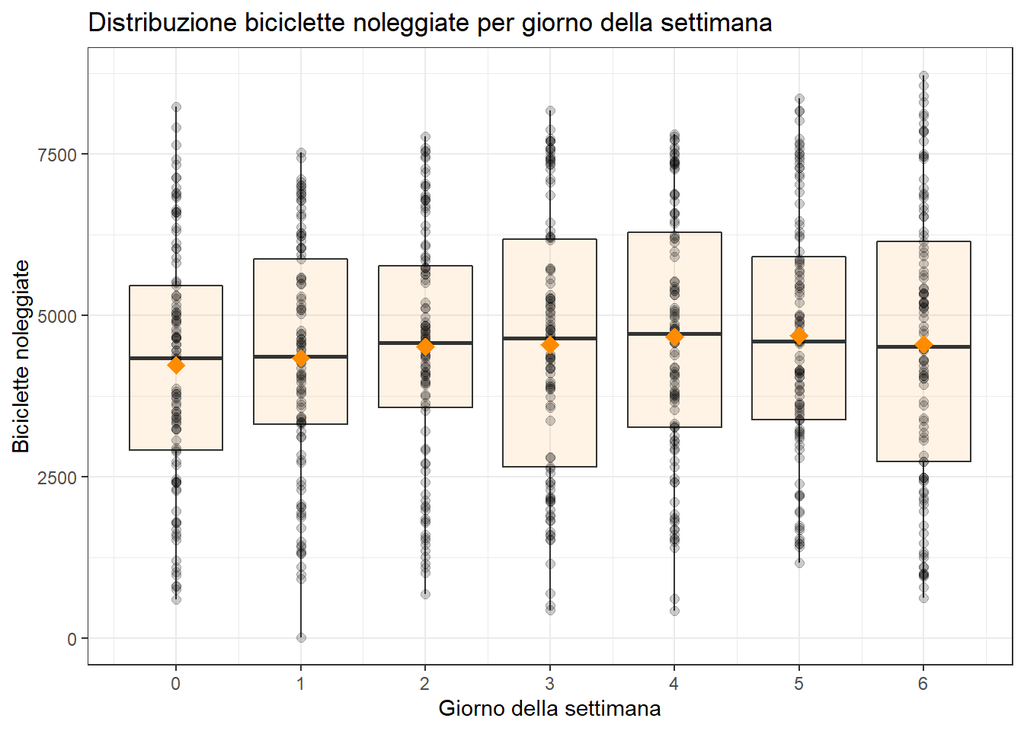

```r
ggplot(data = bsh, aes(x = weekday, y = cnt, group = weekday)) +
  geom_boxplot(fill = "darkorange", alpha=0.1, coef = 10) +
  geom_jitter(width = 0, height = 0, alpha = 0.2, col = "black", size=2) +
  stat_summary(fun = "mean", geom = "point", col = "darkorange", pch = 18, size = 4) +
  labs(x = "Giorno della settimana", y = "Biciclette noleggiate", title = "Distribuzione biciclette noleggiate per giorno della settimana") +
  scale_x_continuous(breaks = 0:12)+
  theme_bw()
```

Calcoliamo la temperatura media mensile e le percentuale di biciclette noleggiate per mese da i diversi gruppi di utenti:

```r
bsharing <- bsh %>%
  mutate(mese = mnth,
         tot_affitti = sum(cnt),
         tot_registrati = sum(registered),
         tot_non_registrati = sum(casual)) %>%
  group_by(mese) %>%
  summarise(aggr_mese_noleggi = sum(cnt),
            aggr_mese_registrati = sum(registered),
            aggr_mese_non_registrati = sum(casual),
            media_temp = mean(temp)) %>%
  mutate(tot_noleggi = sum(aggr_mese_noleggi),
         perc_tot_noleggi = aggr_mese_noleggi/tot_noleggi*100,
         tot_registrati = sum(aggr_mese_registrati),
         perc_registrati = aggr_mese_registrati/tot_registrati*100,
         tot_non_registrati = sum(aggr_mese_non_registrati),
         perc_non_registrati = aggr_mese_non_registrati/tot_non_registrati*100) %>%
  summarise(mese, media_temp, perc_tot_noleggi, perc_registrati, perc_non_registrati)

bsharing
```

```
## # A tibble: 12 x 5
##     mese media_temp perc_tot_noleggi perc_registrati perc_non_registrati
##    <int>      <dbl>            <dbl>           <dbl>               <dbl>
##  1     1       9.69             4.10            4.60                1.94
##  2     2      12.3              4.60            5.10                2.41
##  3     3      16.0              6.95            6.90                7.17
##  4     4      19.3              8.17            7.79                9.81
##  5     5      24.4             10.1             9.59               12.1
##  6     6      28.0             10.5            10.2                11.9
##  7     7      31.0             10.5             9.98               12.6
##  8     8      29.1             10.7            10.4                11.6
##  9     9      25.3             10.5            10.3                11.3
## 10    10      19.9              9.79            9.83                9.64
## 11    11      15.1              7.74            8.17                5.90
## 12    12      13.3              6.41            7.08                3.50
```

Visualizziamo la variazione del conto delle biciclette noleggiate dalle diverse categorie di utenti e la media della temperatura (adattata per essere visualizzata al meglio) per settimana:

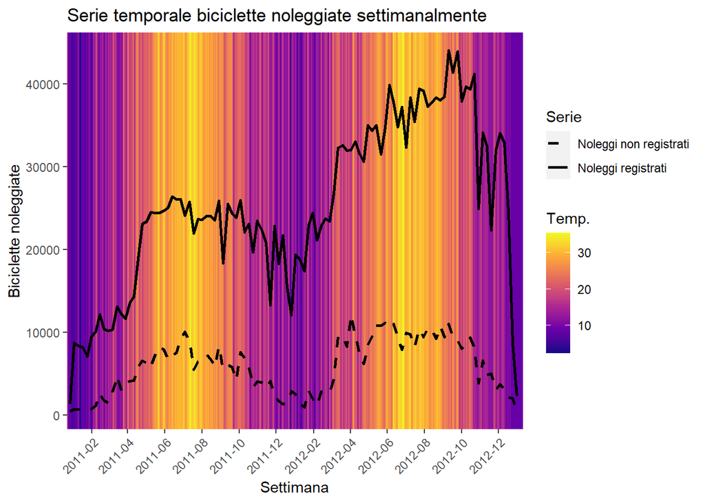

```r
weekly <- bsh %>%
  mutate(Week = as.Date(cut(dteday, breaks = "week")))%>%
  group_by(Week) %>%
  summarise('Noleggi non registrati' = sum(casual), 'Noleggi registrati' = sum(registered)) %>%
  gather(key = "Serie", value = "value", -Week)


ggplot(data = weekly) +
  geom_rect(data= bsh, aes(xmin=dteday-10,xmax=dteday+10,ymin=Inf,ymax=-Inf,
      fill=temp)) +
  scale_fill_viridis_c(name = "Temp.", option = "C") +
  geom_line(aes(x = Week, y = value, color = Serie, linetype = Serie), size = 1) +
  scale_x_date(date_labels = "%Y-%m", date_breaks = "2 month", expand = c(0, 0)) +
  theme(axis.text.x = element_text(angle =45, hjust = 1)) +
  scale_linetype_manual(values=c("dashed", "solid")) +
  scale_color_manual(values=c('black', 'black')) +
  labs(x = "Settimana", y = "Biciclette noleggiate", title = "Serie temporale biciclette noleggiate settimanalmente")
```

Queste sembrano correlate in quanto con l’innalzamento della temperatura si nota una conseguente variazione positiva del numeto di noleggi.

Proviamo a svolgere una regressione per vedere se la variabile conto delle biciclette affittate è correlata alla temperatura e quanto questa correlazione sia forte.

Controlliamo se vi è linearità nella relazione fra le variabili:

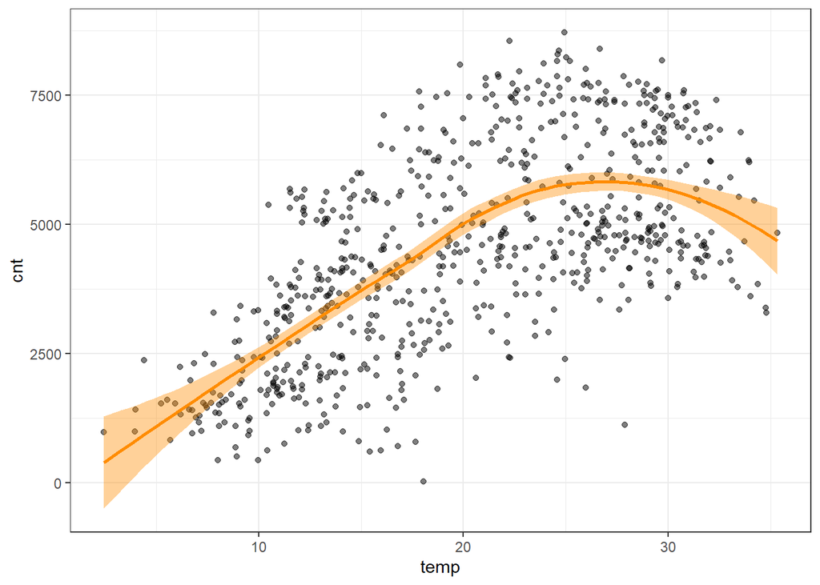

```r
ggplot(data = bsh, mapping = aes(x = temp, y = cnt), color=black) +
  geom_point(alpha = 0.5) +
  stat_smooth(color = "darkorange", fill = "darkorange", method = "loess") +
  theme_bw()
```

Vi è una certa linearità fino al valore temp 0.6, che rappresenta i 24.6 gradi Celsius, ma oltre questa soglia la relazione fra le variabili tende a curvarsi.

##Analisi di Regressione

Regressione lineare

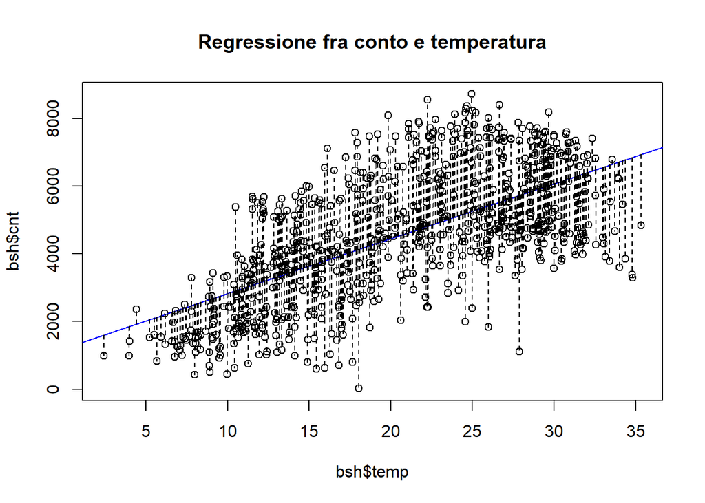

```r
plot(bsh$temp, bsh$cnt)
retta=lm(bsh$cnt ~ bsh$temp)
abline(retta, col="blue")
segments(bsh$temp, fitted(retta), bsh$temp, bsh$cnt, lty=2)
title(main="Regressione fra conto e temperatura")
```

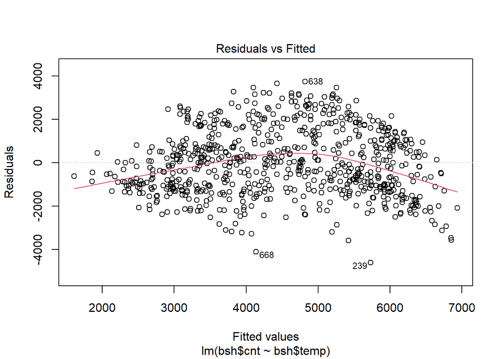

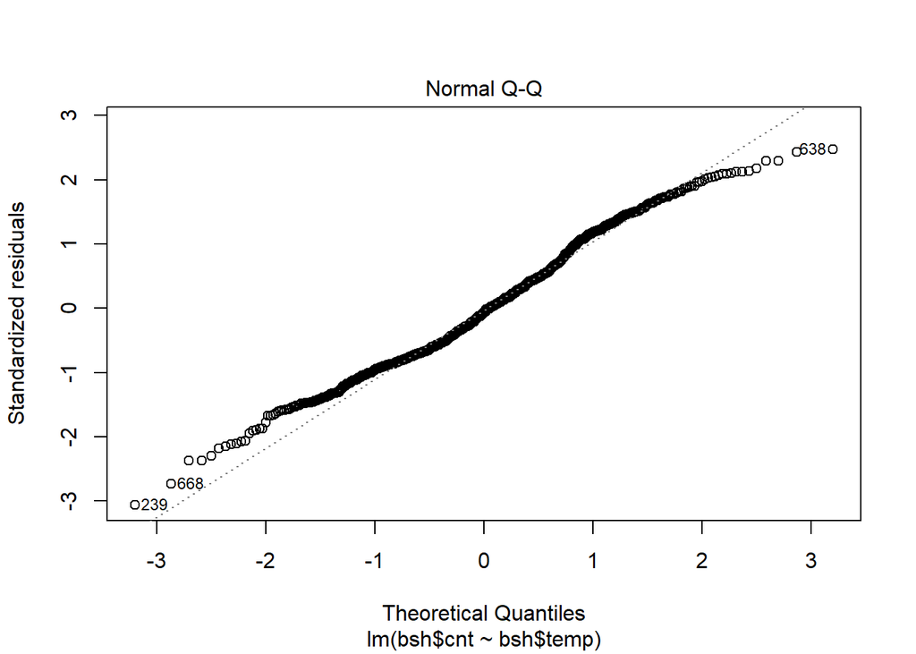

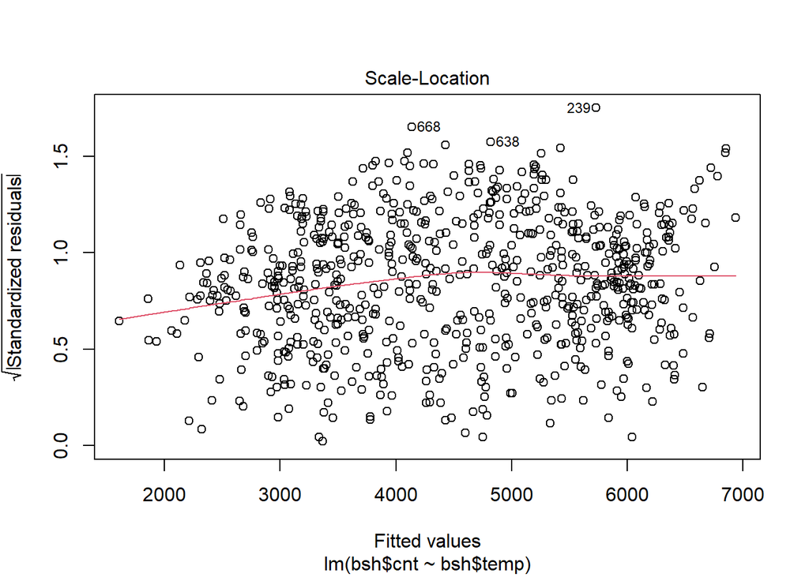

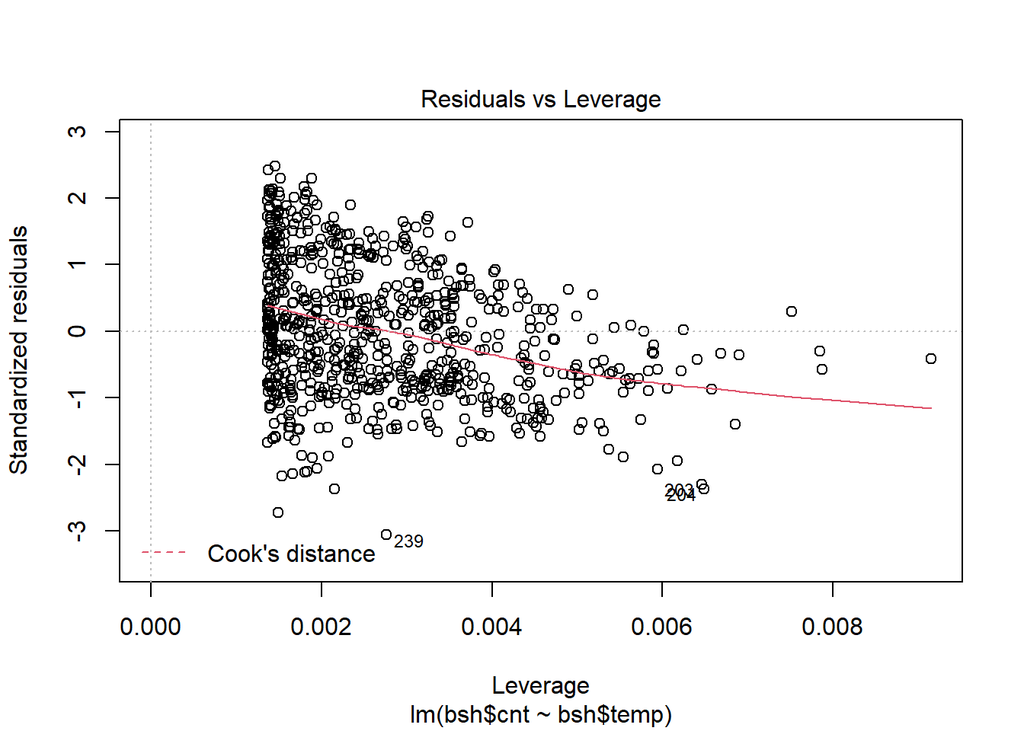

```r
plot(retta)
```

```r
summary(retta)
```

```
##
## Call:
## lm(formula = bsh$cnt ~ bsh$temp)
##
## Residuals:
##     Min      1Q  Median      3Q     Max
## -4615.3 -1134.9  -104.4  1044.3  3737.8
##
## Coefficients:
##             Estimate Std. Error t value Pr(>|t|)
## (Intercept) 1214.642    161.164   7.537 1.43e-13 ***
## bsh$temp     161.969      7.444  21.759  < 2e-16 ***
## ---
## Signif. codes:  0 '***' 0.001 '**' 0.01 '*' 0.05 '.' 0.1 ' ' 1
##
## Residual standard error: 1509 on 729 degrees of freedom
## Multiple R-squared:  0.3937, Adjusted R-squared:  0.3929
## F-statistic: 473.5 on 1 and 729 DF,  p-value: < 2.2e-16
```

Questa analisi ci restituisce un r quadro di 0.39 ma visualizzando i dati e le distanze fra i punti e la retta si intuisce che una regressione parabolica potrebbe fare ottenere risultati migliori.

Regressione parabolica

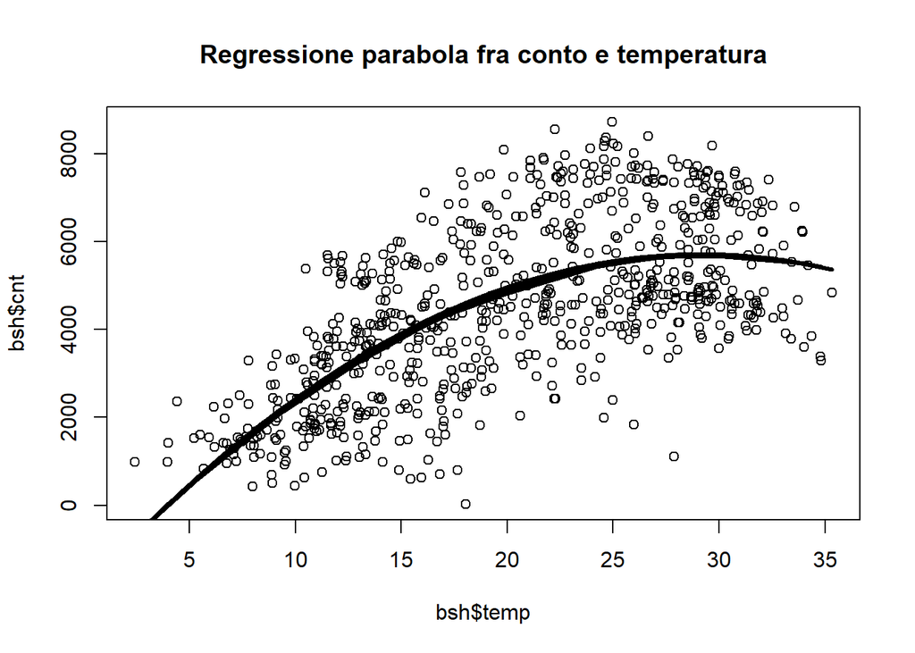

```r
plot(bsh$temp, bsh$cnt)
temp2 = bsh$temp^2
parabola = lm(bsh$cnt ~ bsh$temp + temp2)
lines(bsh$temp, fitted(parabola), lwd = 3)
title(main="Regressione parabola fra conto e temperatura")
```

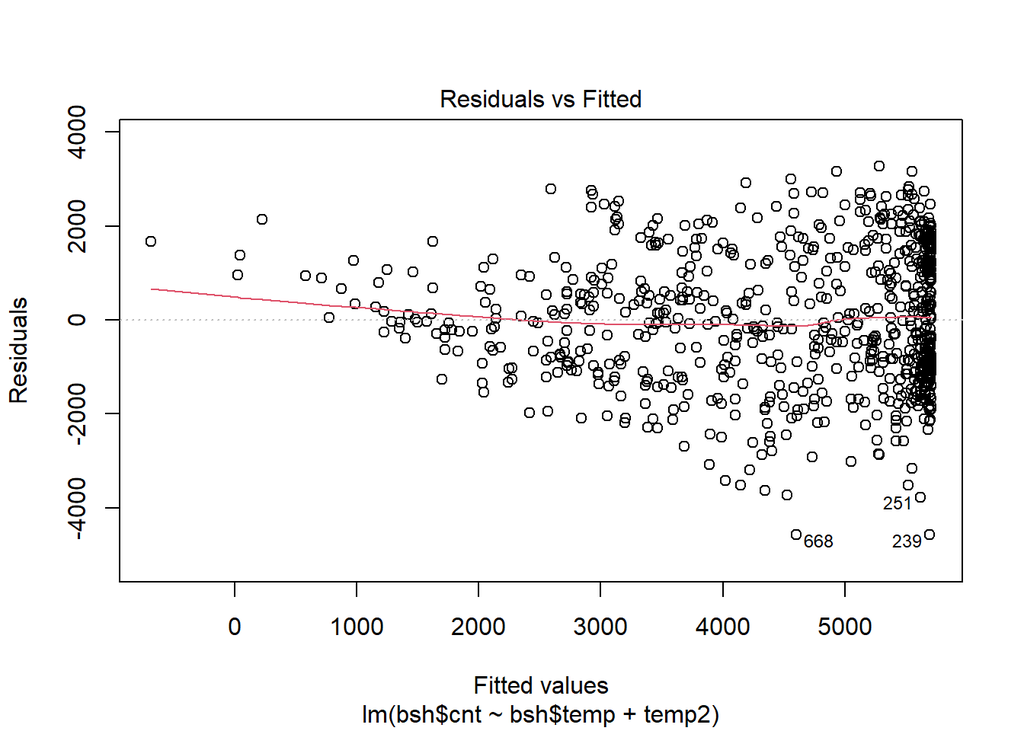

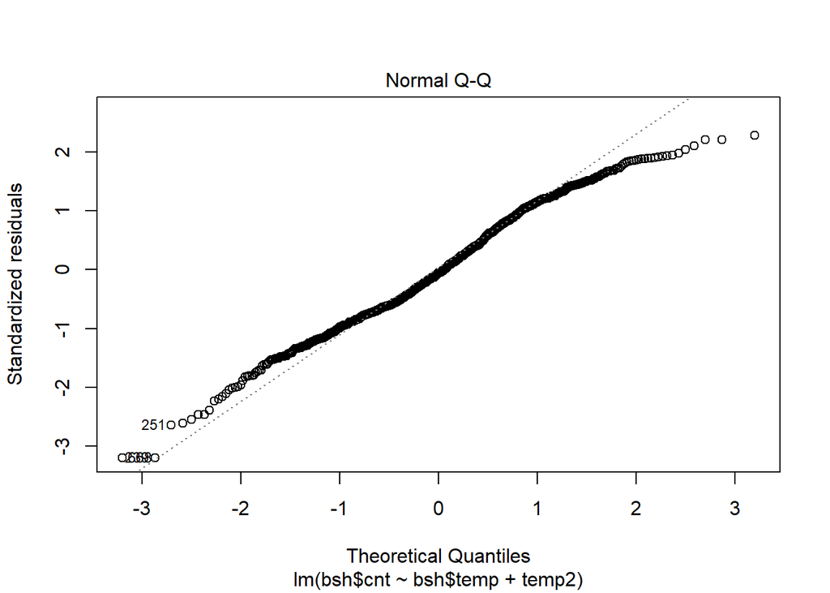

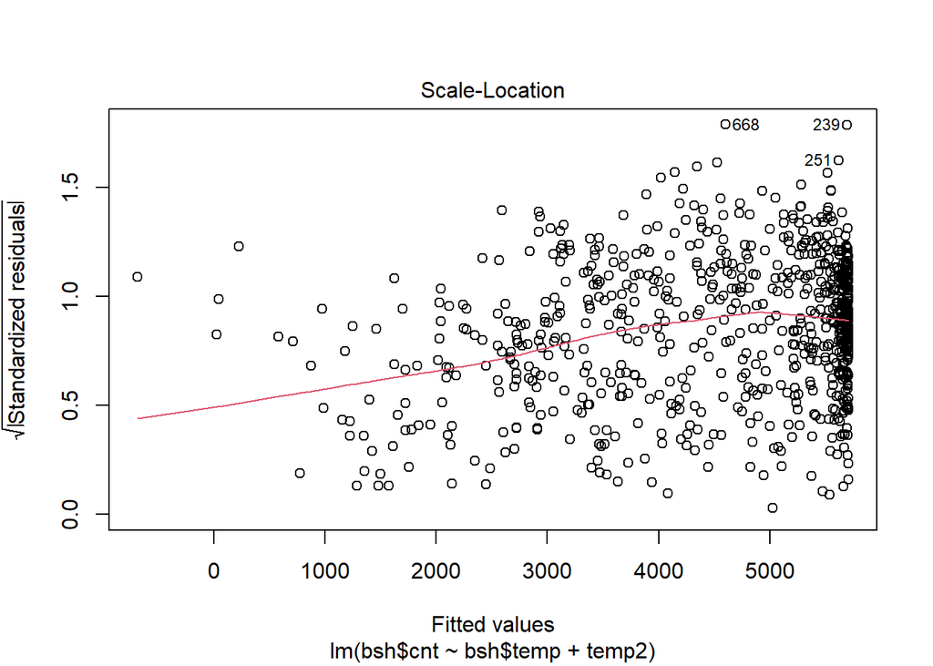

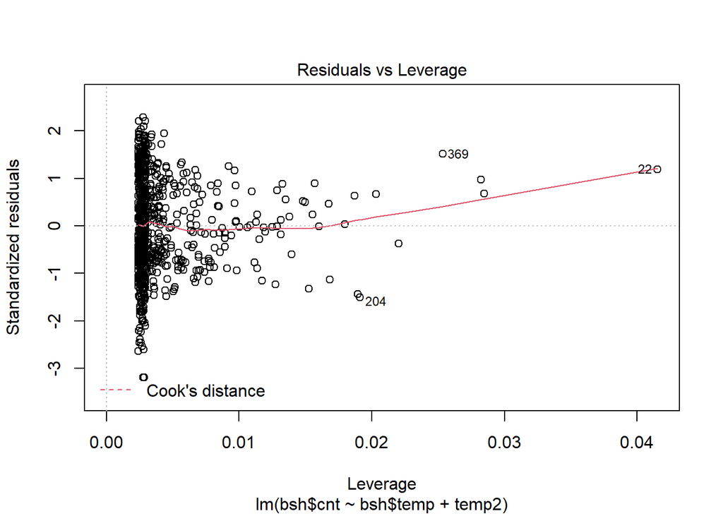

```r
plot(parabola)
```

```r
summary(parabola)
```

```
##
## Call:
## lm(formula = bsh$cnt ~ bsh$temp + temp2)
##
## Residuals:
##     Min      1Q  Median      3Q     Max
## -4580.4 -1043.6   -79.1  1150.7  3274.5
##
## Coefficients:
##              Estimate Std. Error t value Pr(>|t|)
## (Intercept) -1901.956    382.391  -4.974 8.19e-07 ***
## bsh$temp      522.120     41.102  12.703  < 2e-16 ***
## temp2          -8.956      1.007  -8.895  < 2e-16 ***
## ---
## Signif. codes:  0 '***' 0.001 '**' 0.01 '*' 0.05 '.' 0.1 ' ' 1
##
## Residual standard error: 1434 on 728 degrees of freedom
## Multiple R-squared:  0.4532, Adjusted R-squared:  0.4517
## F-statistic: 301.7 on 2 and 728 DF,  p-value: < 2.2e-16
```

Questo modello restituisce un r quadro di 0.45, sottolineando una correlazione di una certa rilevanza.

2012:

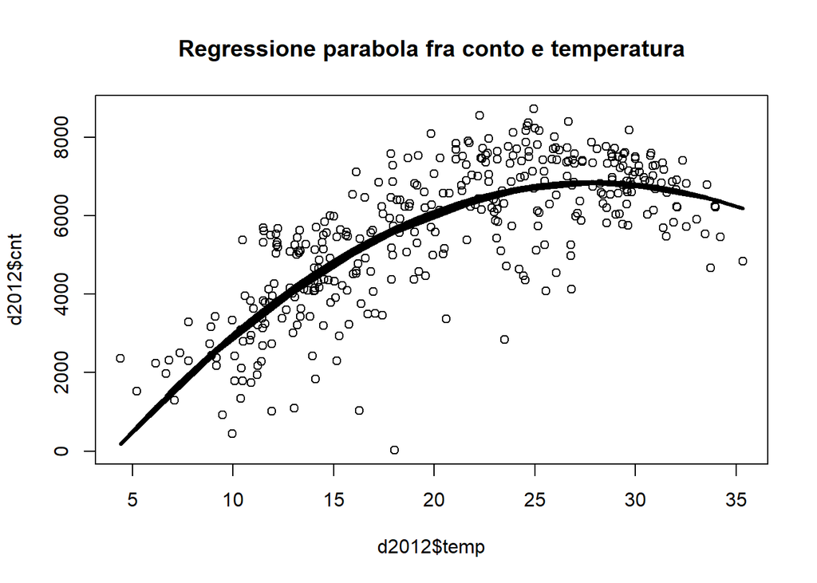

```r
d2012 <- bsh %>%
  filter(yr==1)
plot(d2012$temp, d2012$cnt)
temp2012 = d2012$temp^2
parabola2012 = lm(d2012$cnt ~ d2012$temp + temp2012)
lines(d2012$temp, fitted(parabola2012), lwd = 3)
title(main="Regressione parabola fra conto e temperatura")
```

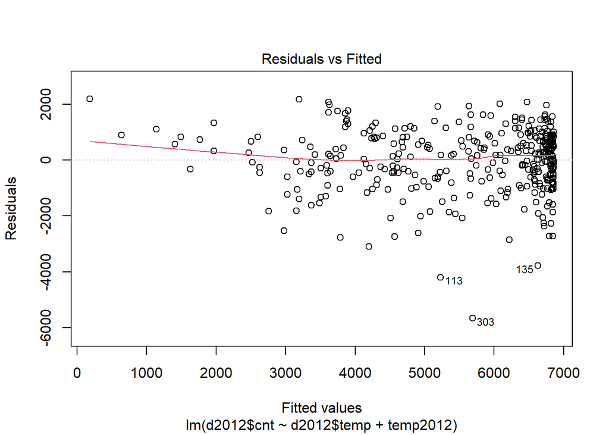

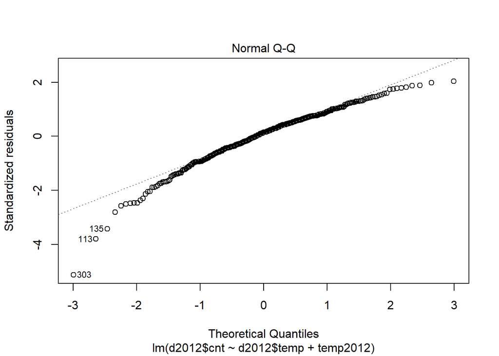

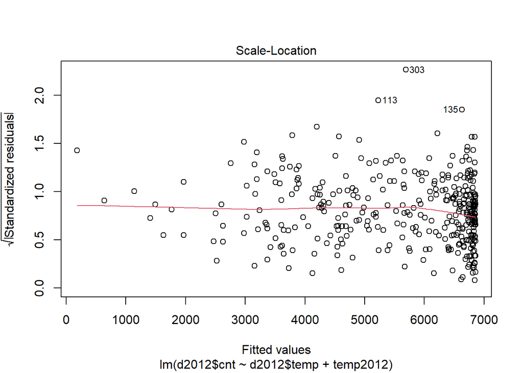

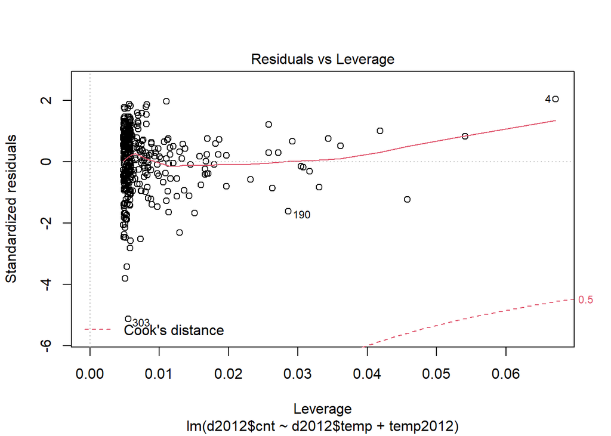

```r
plot(parabola2012)
```

```r
summary(parabola2012)
```

```
##
## Call:
## lm(formula = d2012$cnt ~ d2012$temp + temp2012)
##
## Residuals:
##     Min      1Q  Median      3Q     Max
## -5668.0  -602.9   165.1   761.3  2186.8
##
## Coefficients:
##             Estimate Std. Error t value Pr(>|t|)
## (Intercept) -2566.77     475.06  -5.403 1.19e-07 ***
## d2012$temp    677.06      49.59  13.654  < 2e-16 ***
## temp2012      -12.16       1.19 -10.223  < 2e-16 ***
## ---
## Signif. codes:  0 '***' 0.001 '**' 0.01 '*' 0.05 '.' 0.1 ' ' 1
##
## Residual standard error: 1107 on 363 degrees of freedom
## Multiple R-squared:  0.6191, Adjusted R-squared:  0.617
## F-statistic: 295.1 on 2 and 363 DF,  p-value: < 2.2e-16
```

2011:

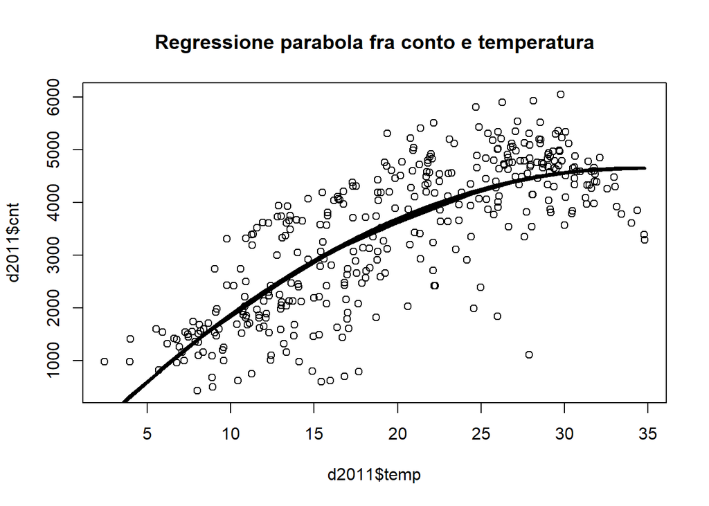

```r
d2011 <- bsh %>%
  filter(yr==0)
plot(d2011$temp, d2011$cnt)
temp2011 = d2011$temp^2
parabola2011 = lm(d2011$cnt ~ d2011$temp + temp2011)
lines(d2011$temp, fitted(parabola2011), lwd = 3)
title(main="Regressione parabola fra conto e temperatura")
```

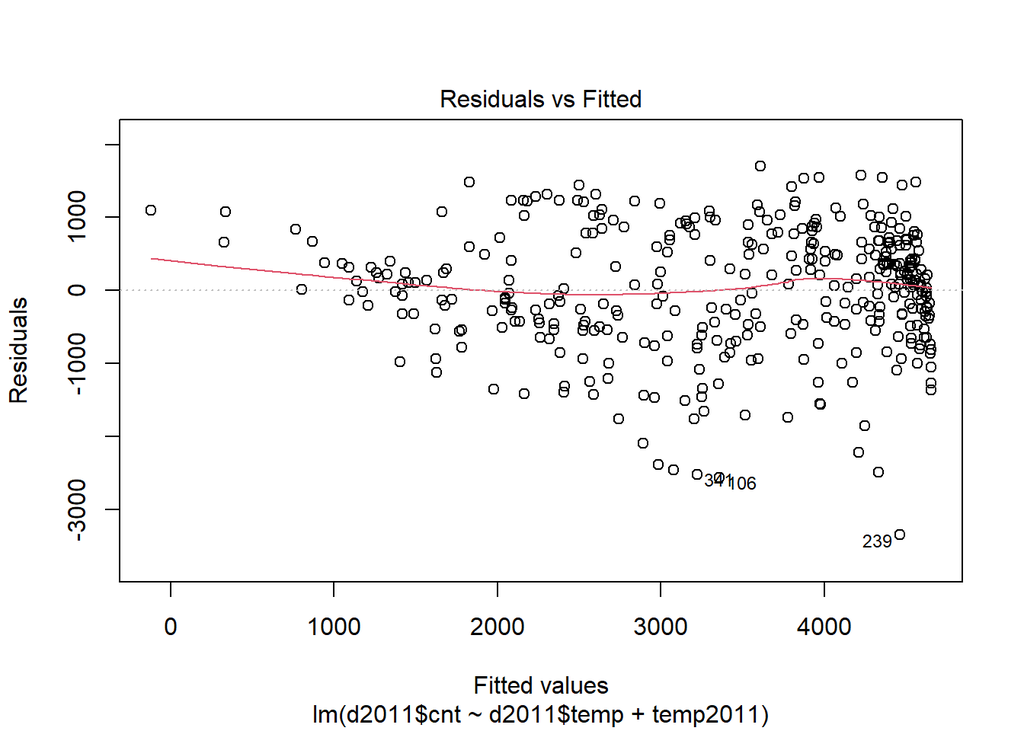

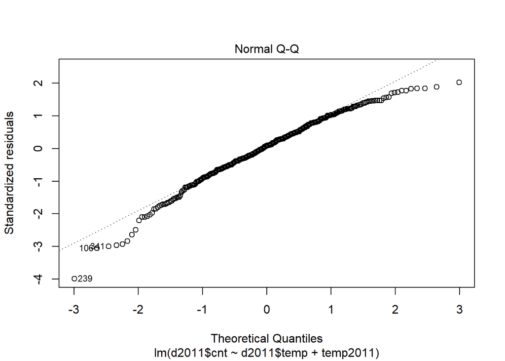

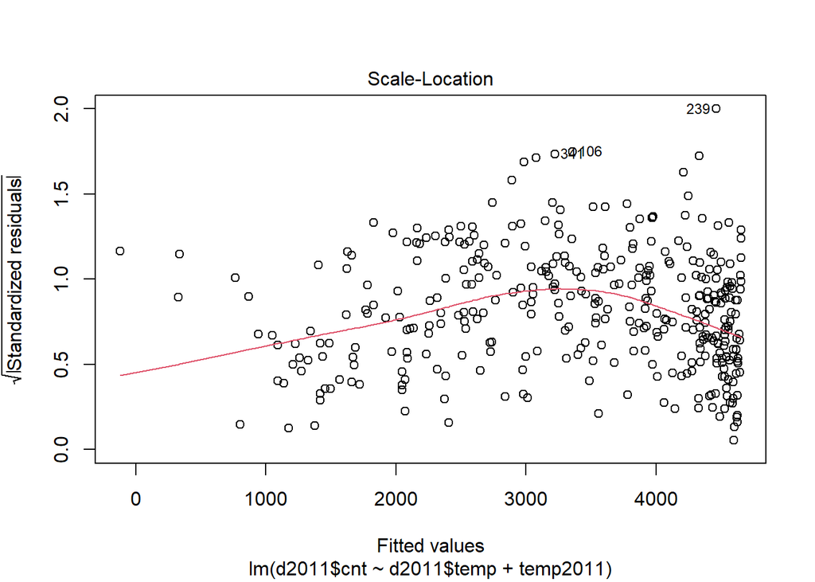

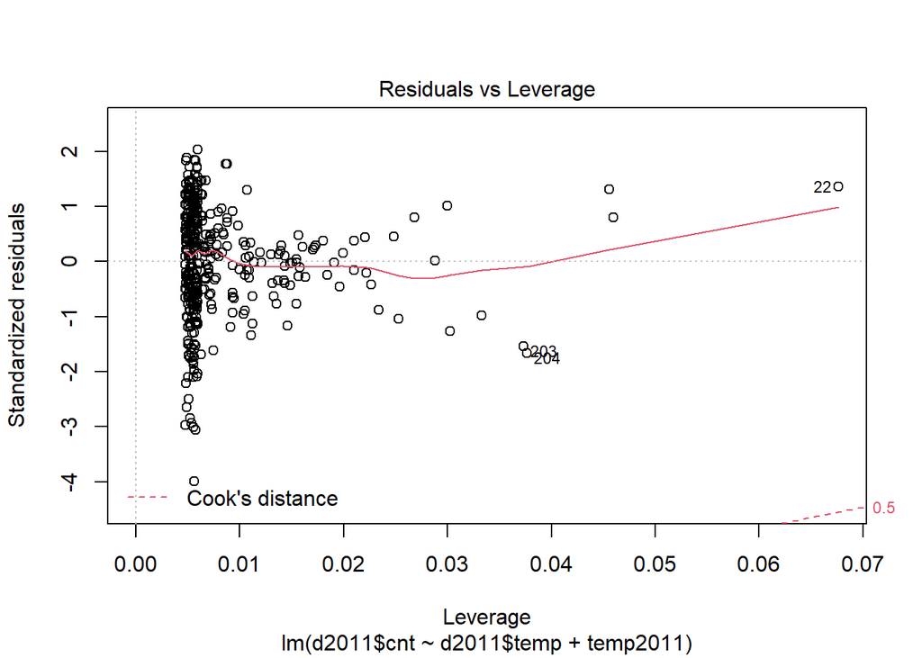

```r
plot(parabola2011)
```

```r
summary(parabola2011)
```

```
##
## Call:
## lm(formula = d2011$cnt ~ d2011$temp + temp2011)
##
## Residuals:
##     Min      1Q  Median      3Q     Max
## -3346.3  -491.6    75.1   630.2  1701.9
##
## Coefficients:
##              Estimate Std. Error t value Pr(>|t|)
## (Intercept) -874.9455   287.5184  -3.043  0.00251 **
## d2011$temp   322.8675    31.7788  10.160  < 2e-16 ***
## temp2011      -4.7155     0.7924  -5.951 6.31e-09 ***
## ---
## Signif. codes:  0 '***' 0.001 '**' 0.01 '*' 0.05 '.' 0.1 ' ' 1
##
## Residual standard error: 840 on 362 degrees of freedom
## Multiple R-squared:  0.6309, Adjusted R-squared:  0.6288
## F-statistic: 309.4 on 2 and 362 DF,  p-value: < 2.2e-16
```

#Conclusioni Abbiamo esplorato vari pacchetti di r per svolgere questa analisi e provato a costruire vari tipi di visualizzazioni. Questo ci ha permesso di comprendere meglio il dataset. nell’opinione dell’autore Le tecniche utilizzate non sono le più efficaci per raggiungere gli obbiettivi del progetto ma abbiamo comunque potuto notare che vi è una certa relazione fra temperature e affitti la regressione non ha dato buoni risultati in quanto non sia il modello adatto al dataset.

```r
library(ggpmisc)
```

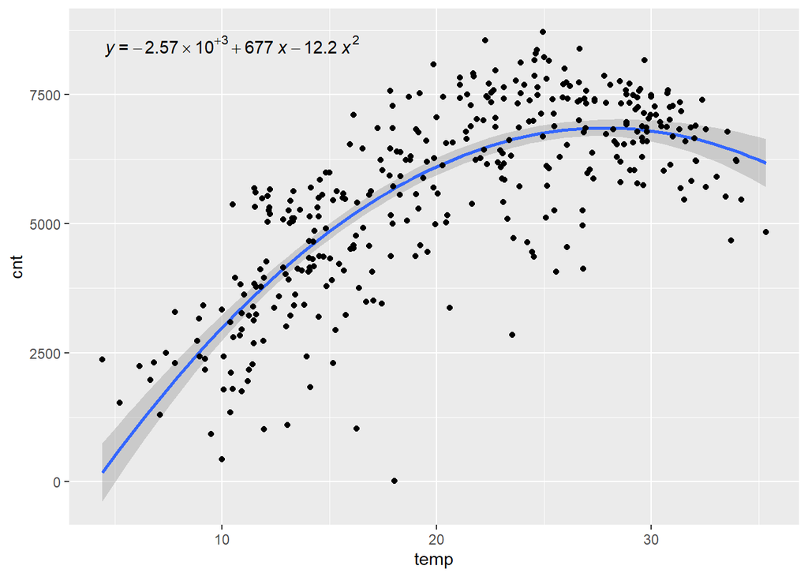

```r
# fitting a polynomial
ggplot(data = d2012, aes(x = temp, y = cnt)) +
  stat_poly_line(formula = y ~ poly(x, 2, raw = TRUE)) +
  stat_poly_eq(formula = y ~ poly(x, 2, raw = TRUE),
               aes(label = after_stat(eq.label))) +
  geom_point()
```